# Untitled

## Problem Statement

We are trying to construct a fraud prevention system, which could allow the business to detect the fraud easily before big damage is done and improve the customer experience with higher accuracy fraud detection.

## Read in Data

```r
library(tidyverse)
train_i <- read_csv("train_identity.csv")
train_t <- read_csv("train_transaction.csv")
train <- left_join(train_t, train_i, by = "TransactionID")
```

```r
test_i <- read_csv("test_identity.csv")
test_t <- read_csv("test_transaction.csv")
test <- left_join(test_t, test_i, by = "TransactionID")
```

```r
dim(train)
```

```
## [1] 590540    434
```

```r
dim(test)
```

```
## [1] 506691    433
```

## Outcome Variable

```r
table(train$isFraud)
```

```
##
##      0      1
## 569877  20663
```

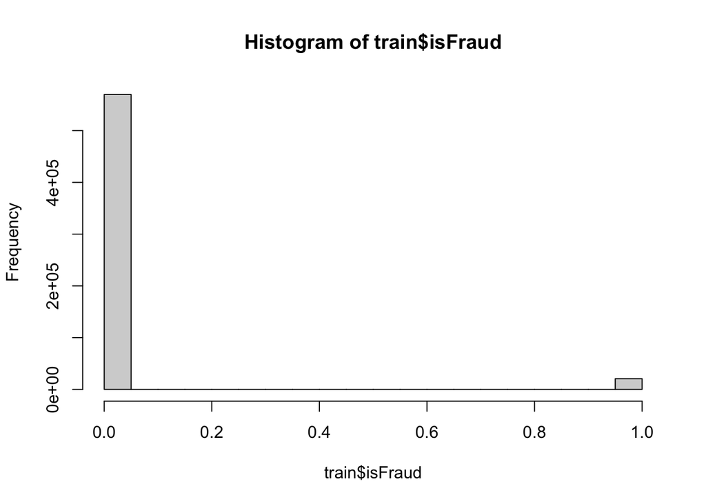

```r
hist(train$isFraud)
```

## Variable Description

- Transaction Table

*TransactionDT:* timedelta froma given reference datetime(not an actual timestamp)

*TransactionAMT:* transactionpayment amount in USD

*ProductCD:* productcodetheproduct for each transaction

*card1-card6:*payment card information,such as card type,card category,issue bank,country. etc.

*addr:*address

*dist:*distance

*P_and(R) email domain:* purchaser and recipient email domain

*C1-C14:*counting,such as how many addresses are found to be associated with the payment card, etc.The actual meaning is masked.

*D1-D15:* timedelta such as days between previous transaction,etc.

*M1-M9:* match such as names on card and address etc.

*Vxxx:* Vesta engineered rich features,including ranking,counting,and other entity relations.

*Categorical Features:* ProductCD card1-card6 addr1,addr2 P_emaildomain R_email domain M1-M9

- Identity Table

Variables in this table are identity information-network connection information (IP,ISP,Proxy,etc) and digital signature(UA/browser/os/versionetc)associated with transactions.

They’re collected byVesta’s fraud protection system and digital security partners. (The field names are masked and pairwise dictionary will not be provided for privacy protection and contract agreement)

*Categorical Features:* DeviceType Devicelnfo id_12-id_38

## Steps of analyzing

1. Clean the data
2. EDA
3. Oversampling step, because of imbalanced outcome variable, will use bootstrap technique
4. Use PCA to reduce dimension
5. Implement classification models: logistic, knn, random forest
6. Model evaluation, confusion matrix, model accuracy and recall, ROC curve